# IODS course project

# Dimensionality reduction techniques

```r
# this definition for knitting at the start of the document sets some rules for the figure sizes which will help as the standard rules might make unreadable figures
knitr::opts_chunk$set(fig.width=12, fig.height=8)
```

This week we will learn about dimension reduction techniques.

We will work with the previously wrangled human development index data.

Load up some libraries we might need.

```r
library(dplyr)
library(GGally)
library(FactoMineR)
library(tidyr)
```

```r
human = read.csv("human2.csv", as.is = TRUE, header = TRUE)
```

First we change the column X back to rown names and remove that column so we have countries again as row names.

```r
rownames(human) = human$X
human = human[c(2:9)]
```

```r
summary(human)
```

```
##   edu2F_edu2M       labf_labm         Edu_exp         Life_exp
##  Min.   :0.1717   Min.   :0.1857   Min.   : 5.40   Min.   :49.00
##  1st Qu.:0.7264   1st Qu.:0.5984   1st Qu.:11.25   1st Qu.:66.30
##  Median :0.9375   Median :0.7535   Median :13.50   Median :74.20
##  Mean   :0.8529   Mean   :0.7074   Mean   :13.18   Mean   :71.65
##  3rd Qu.:0.9968   3rd Qu.:0.8535   3rd Qu.:15.20   3rd Qu.:77.25
##  Max.   :1.4967   Max.   :1.0380   Max.   :20.20   Max.   :83.50
##       GNI           MAt_mortr       Adol_birthr     Femperc_in_parl
##  Min.   :   581   Min.   :   1.0   Min.   :  0.60   Min.   : 0.00
##  1st Qu.:  4198   1st Qu.:  11.5   1st Qu.: 12.65   1st Qu.:12.40
##  Median : 12040   Median :  49.0   Median : 33.60   Median :19.30
##  Mean   : 17628   Mean   : 149.1   Mean   : 47.16   Mean   :20.91
##  3rd Qu.: 24512   3rd Qu.: 190.0   3rd Qu.: 71.95   3rd Qu.:27.95
##  Max.   :123124   Max.   :1100.0   Max.   :204.80   Max.   :57.50
```

Let’s visualize the data with *ggpairs* using the **GGally** package.

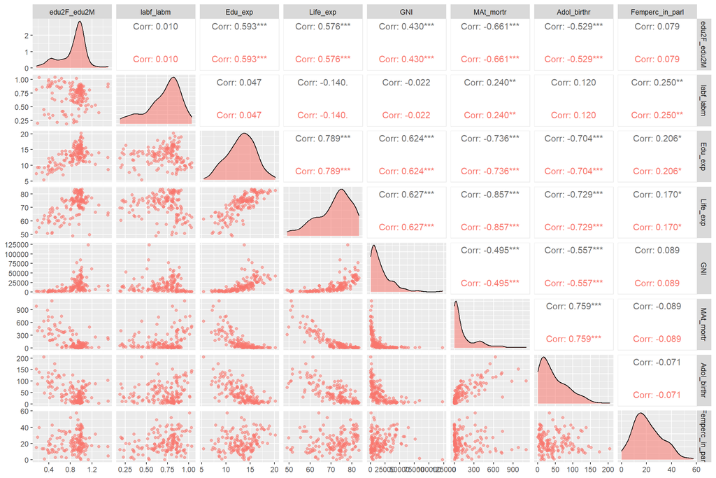

```r
ggpairs(human, mapping = aes(alpha = 0.5, color = "Corr"))
```

From the out look Education female/male ratio, labour female/male ratio, education expectation and percent of females in parlament all seem to be somewhat normally distributed.

GNI and Maternal mortality, adolescent birthrate look abit like poisson distributed.

GNI is most positively correlated with education expectation and life expectancy. GNI is also negatively correlated with adolescent birthrate and maternal mortality. So countries with high GNI also have high education expectation and life expectancy but low adolescent birthrate and low maternal mortality.

Let’s make a principal component analysis.

```r
# model with prcomp and summary of the model
pca_human = prcomp(human)
summary(pca_human)
```

```
## Importance of components:
##                              PC1      PC2   PC3   PC4   PC5   PC6    PC7    PC8
## Standard deviation     1.854e+04 185.5219 25.19 11.45 3.766 1.566 0.1912 0.1591
## Proportion of Variance 9.999e-01   0.0001  0.00  0.00 0.000 0.000 0.0000 0.0000
## Cumulative Proportion  9.999e-01   1.0000  1.00  1.00 1.000 1.000 1.0000 1.0000
```

We’ll try the plotting anyway even though the summary looks pretty bad.

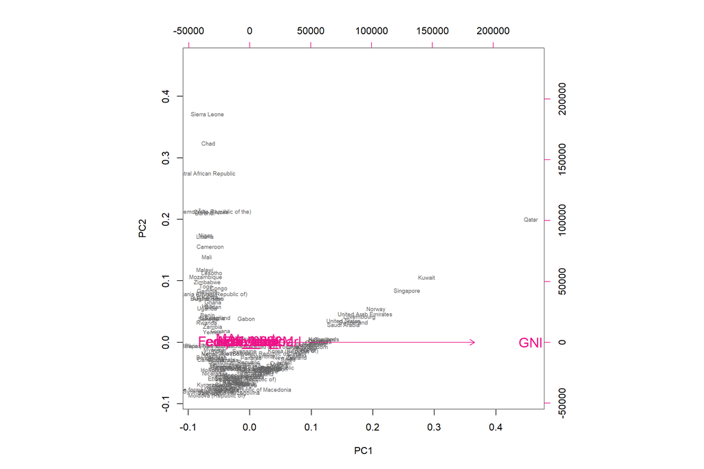

```r
# visualization with the stat package biplot
biplot(pca_human, choices = 1:2, cex = c(0.6, 1.4), col = c("grey40", "deeppink2"))
```

The unstandardized modeling seems to quite bad. Only GNI has some kind of effect visible. The grouping of countries is also bad and they all seem clustered in the bottom left corner. There really isn’t much point to analyze this un-standardized data any further.

Let’s standardize the variables and try the analysis again.

```r
# standardise and create the model with the standardized data
human_std = scale(human)
pca_std = prcomp(human_std)
```

Then lets look at the model summary.

```r
summary(pca_std)
```

```
## Importance of components:
##                           PC1    PC2     PC3     PC4     PC5     PC6     PC7
## Standard deviation     2.0708 1.1397 0.87505 0.77886 0.66196 0.53631 0.45900
## Proportion of Variance 0.5361 0.1624 0.09571 0.07583 0.05477 0.03595 0.02634
## Cumulative Proportion  0.5361 0.6984 0.79413 0.86996 0.92473 0.96069 0.98702
##                            PC8
## Standard deviation     0.32224
## Proportion of Variance 0.01298
## Cumulative Proportion  1.00000
```

Now this looks good already and the results seem much better.

Let’s try to plot this. Let’s take the first two principal components since they already explain some 70% of the variances.

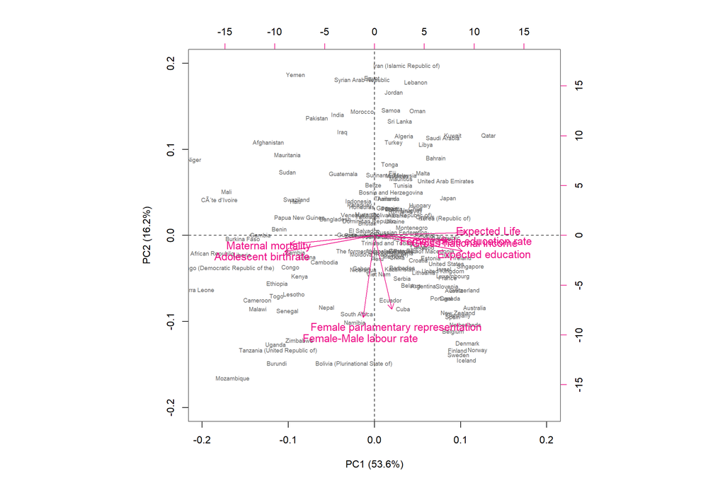

```r
# We'll use biplot to make the pca plot and ablines to give us the grid so we can group up countries in different quadrants

biplot(pca_std, xlim = c(-0.2, 0.2), ylim = c(-0.2, 0.2), choices = 1:2, cex = c(0.6, 1.1), col = c("grey40", "deeppink2"), ylabs = c("Female-male education rate", "Female-Male labour rate", "Expected education", "Expected Life", "Gross national income", "Adolescent birthrate", "Maternal mortality", "Female parlamentary representation"), xlab = "PC1 (53.6%)", ylab = "PC2 (16.2%)")
abline(h = 0, v = 0 ,lwd = 1, col = "grey20", lty = 2)
```

In general the countries on the right side of the plot have higher GNI and expected life time and expected study times and countries on the left side have higher maternal mortality as well as higher adolescent birthrate. Countries on the upper part have lower female representation and participation in the society while countries on the bottom are the opposite. These would be the two principal components of the model and they explain some 70% of the variances between countries.

From this standardized data we can see a pretty good variance between the variables and in the groupings of countries. For example all the Nordic countries are grouped in the bottom right with high female parliamentary representation and high female-male labour rate, as well as high GNI, expected life and education time and high female-male education rate. These countries also have low maternal mortality and low adolescent birthrate.

Many African countries seem to be on the left side with low GNI and high maternal mortality as well as low expected education and life times. Arab countries seem to have decent to good GNI with decent life and education expectancy but poor female representation.

Next we will look at the teaset from the package **FactoMineR**.

We start by loading the dataset.

```r
# use data(tea) to load-up the dataset from the FactoMineR package
data(tea)
summary(tea)
```

```
##          breakfast           tea.time          evening          lunch
##  breakfast    :144   Not.tea time:131   evening    :103   lunch    : 44
##  Not.breakfast:156   tea time    :169   Not.evening:197   Not.lunch:256
##
##
##
##
##
##         dinner           always          home           work
##  dinner    : 21   always    :103   home    :291   Not.work:213
##  Not.dinner:279   Not.always:197   Not.home:  9   work    : 87
##
##
##
##
##
##         tearoom           friends          resto          pub
##  Not.tearoom:242   friends    :196   Not.resto:221   Not.pub:237
##  tearoom    : 58   Not.friends:104   resto    : 79   pub    : 63
##
##
##
##
##
##         Tea         How           sugar                     how
##  black    : 74   alone:195   No.sugar:155   tea bag           :170
##  Earl Grey:193   lemon: 33   sugar   :145   tea bag+unpackaged: 94
##  green    : 33   milk : 63                  unpackaged        : 36
##                  other:  9
##
##
##
##                   where                 price          age        sex
##  chain store         :192   p_branded      : 95   Min.   :15.00   F:178
##  chain store+tea shop: 78   p_cheap        :  7   1st Qu.:23.00   M:122
##  tea shop            : 30   p_private label: 21   Median :32.00
##                             p_unknown      : 12   Mean   :37.05
##                             p_upscale      : 53   3rd Qu.:48.00
##                             p_variable     :112   Max.   :90.00
##
```

[output cut: 25 more lines]

```
##  feminine    :129   Not.sophisticated: 85   No.slimming:255   exciting   :116
##  Not.feminine:171   sophisticated    :215   slimming   : 45   No.exciting:184
##
##
##
##
##
##         relaxing              effect.on.health
##  No.relaxing:113   effect on health   : 66
##  relaxing   :187   No.effect on health:234
##
##
##
##
##
```

```r
str(tea)
```

```
## 'data.frame':    300 obs. of  36 variables:
##  $ breakfast       : Factor w/ 2 levels "breakfast","Not.breakfast": 1 1 2 2 1 2 1 2 1 1 ...
##  $ tea.time        : Factor w/ 2 levels "Not.tea time",..: 1 1 2 1 1 1 2 2 2 1 ...
##  $ evening         : Factor w/ 2 levels "evening","Not.evening": 2 2 1 2 1 2 2 1 2 1 ...
##  $ lunch           : Factor w/ 2 levels "lunch","Not.lunch": 2 2 2 2 2 2 2 2 2 2 ...
##  $ dinner          : Factor w/ 2 levels "dinner","Not.dinner": 2 2 1 1 2 1 2 2 2 2 ...
##  $ always          : Factor w/ 2 levels "always","Not.always": 2 2 2 2 1 2 2 2 2 2 ...
##  $ home            : Factor w/ 2 levels "home","Not.home": 1 1 1 1 1 1 1 1 1 1 ...
##  $ work            : Factor w/ 2 levels "Not.work","work": 1 1 2 1 1 1 1 1 1 1 ...
##  $ tearoom         : Factor w/ 2 levels "Not.tearoom",..: 1 1 1 1 1 1 1 1 1 2 ...
##  $ friends         : Factor w/ 2 levels "friends","Not.friends": 2 2 1 2 2 2 1 2 2 2 ...
##  $ resto           : Factor w/ 2 levels "Not.resto","resto": 1 1 2 1 1 1 1 1 1 1 ...
##  $ pub             : Factor w/ 2 levels "Not.pub","pub": 1 1 1 1 1 1 1 1 1 1 ...
##  $ Tea             : Factor w/ 3 levels "black","Earl Grey",..: 1 1 2 2 2 2 2 1 2 1 ...
##  $ How             : Factor w/ 4 levels "alone","lemon",..: 1 3 1 1 1 1 1 3 3 1 ...
```

[output cut: 22 more lines]

The tea data has 35 factorial variables and 1 integer variable. Let’s visualize these by barplots where we gather them in two groups for the sake of the printout.

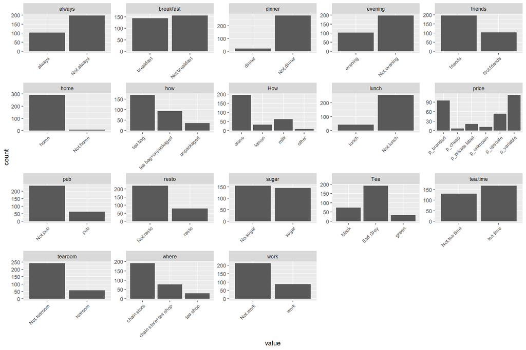

```r
gather(tea[1:18]) %>% ggplot(aes(value)) + facet_wrap("key", scales = "free") + geom_bar() + theme(axis.text.x = element_text(angle = 45, hjust = 1, size = 8))
```

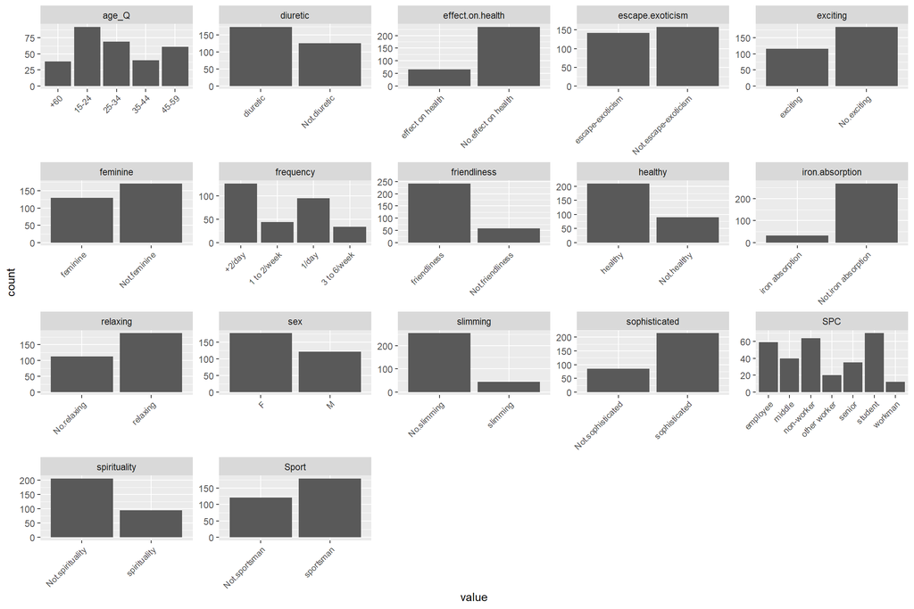

```r
gather(tea[20:36]) %>% ggplot(aes(value)) + facet_wrap("key", scales = "free") + geom_bar() + theme(axis.text.x = element_text(angle = 45, hjust = 1, size = 8))
```

That’s a lot of variables so lets choose a smaller subset of interesting ones of them.

```r
#create a vector for the columns to keep
keep_tea = c("sex", "breakfast", "friends", "evening", "How", "where", "how", "frequency","sugar", "Tea")
tea_keep = dplyr::select(tea, one_of(keep_tea))
```

```r
# create the model from the subset of variables defined previously
tea_mca = MCA(tea_keep, graph = FALSE)
summary(tea_mca)
```

```
##
## Call:
## MCA(X = tea_keep, graph = FALSE)
##
##
## Eigenvalues
##                        Dim.1   Dim.2   Dim.3   Dim.4   Dim.5   Dim.6   Dim.7
## Variance               0.189   0.175   0.159   0.135   0.125   0.118   0.102
## % of var.             11.124  10.288   9.381   7.950   7.338   6.963   5.980
## Cumulative % of var.  11.124  21.412  30.793  38.742  46.080  53.043  59.023
##                        Dim.8   Dim.9  Dim.10  Dim.11  Dim.12  Dim.13  Dim.14
## Variance               0.100   0.089   0.084   0.082   0.075   0.073   0.058
## % of var.              5.901   5.255   4.936   4.796   4.431   4.312   3.397
## Cumulative % of var.  64.924  70.180  75.116  79.911  84.343  88.655  92.052
##                       Dim.15  Dim.16  Dim.17
## Variance               0.053   0.047   0.035
## % of var.              3.093   2.786   2.070
## Cumulative % of var.  95.145  97.930 100.000
##
## Individuals (the 10 first)
##                  Dim.1    ctr   cos2    Dim.2    ctr   cos2    Dim.3    ctr
## 1             | -0.487  0.419  0.181 | -0.375  0.268  0.107 |  0.483  0.487
## 2             | -0.181  0.058  0.021 | -0.645  0.792  0.270 |  0.708  1.049
## 3             |  0.032  0.002  0.001 | -0.040  0.003  0.002 | -0.350  0.256
## 4             | -0.702  0.869  0.472 | -0.257  0.126  0.063 | -0.003  0.000
## 5             | -0.132  0.031  0.016 | -0.249  0.118  0.056 |  0.206  0.089
## 6             | -0.572  0.576  0.317 | -0.269  0.138  0.070 |  0.197  0.081
## 7             | -0.134  0.032  0.012 | -0.093  0.017  0.006 | -0.065  0.009
## 8             | -0.418  0.308  0.086 | -0.061  0.007  0.002 |  0.013  0.000
## 9             |  0.562  0.556  0.190 | -0.360  0.246  0.078 |  0.439  0.403
## 10            |  0.644  0.731  0.240 |  0.016  0.000  0.000 |  0.420  0.370
##                 cos2
## 1              0.178 |
## 2              0.326 |
## 3              0.139 |
## 4              0.000 |
## 5              0.039 |
## 6              0.038 |
## 7              0.003 |
## 8              0.000 |
```

[output cut: 24 more lines]

```
## alone         -0.036  0.053  0.002 -0.846 |
## lemon         -0.529  1.928  0.035 -3.214 |
##
## Categorical variables (eta2)
##                 Dim.1 Dim.2 Dim.3
## sex           | 0.099 0.034 0.022 |
## breakfast     | 0.114 0.163 0.175 |
## friends       | 0.126 0.043 0.263 |
## evening       | 0.011 0.069 0.135 |
## How           | 0.098 0.145 0.061 |
## where         | 0.539 0.499 0.168 |
## how           | 0.404 0.573 0.120 |
## frequency     | 0.353 0.176 0.199 |
## sugar         | 0.080 0.001 0.159 |
## Tea           | 0.066 0.046 0.292 |
```

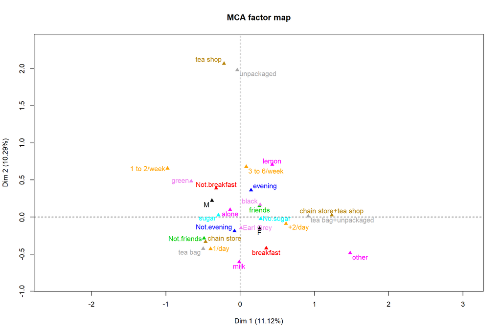

```r
# plot the model for visual inspection
plot(tea_mca, invisible=c("ind"), habillage = "quali", graph.type = "classic")
```

It is difficult to say what the first dimension (x-axis) relates to since there are no clear pairings from the variables. Y-axis could relate to the style of tea drunk and where it is bought from (unpackaged and teashop vs chain store and tea bags). The amount of variances the two first explain is quite small so that also makes it more difficult to interpret.

```r
date()
```

```
## [1] "Fri Dec 10 20:55:30 2021"
```

# Analysis of longitudinal data

```r
# set figure sizes for knitting
knitr::opts_chunk$set(fig.width=12, fig.height=8)
```

Libraries to load up.

```r
library(dplyr)
library(tidyr)
library(ggplot2)
```

First we load up the datasets. We will also need the original RATS data in one of the analyses.

```r
BPRSL = read.csv("BPRSL.csv", as.is = TRUE, header = TRUE, row.names = NULL)

RATSL = read.csv("RATSL.csv", as.is = TRUE, header = TRUE, row.names = NULL)

RATS = read.table("https://raw.githubusercontent.com/KimmoVehkalahti/MABS/master/Examples/data/rats.txt", header = T, sep = '\t')
```

Let’s check the datasets

```r
str(BPRSL)
```

```
## 'data.frame':    360 obs. of  5 variables:
##  $ treatment: int  1 1 1 1 1 1 1 1 1 1 ...
##  $ subject  : int  1 2 3 4 5 6 7 8 9 10 ...
##  $ weeks    : chr  "week0" "week0" "week0" "week0" ...
##  $ bprs     : int  42 58 54 55 72 48 71 30 41 57 ...
##  $ week     : int  0 0 0 0 0 0 0 0 0 0 ...
```

```r
str(RATSL)
```

```
## 'data.frame':    176 obs. of  5 variables:
##  $ ID    : int  1 2 3 4 5 6 7 8 9 10 ...
##  $ Group : int  1 1 1 1 1 1 1 1 2 2 ...
##  $ WD    : chr  "WD1" "WD1" "WD1" "WD1" ...
##  $ Weight: int  240 225 245 260 255 260 275 245 410 405 ...
##  $ Time  : int  1 1 1 1 1 1 1 1 1 1 ...
```

Seems we need to refactor the factorial variables again, we’ll recheck with **str** to see that it worked again.

```r
# use as.factor to transform them back to factorial variables in both datasets and confirm with str
BPRSL$treatment = as.factor(BPRSL$treatment)
BPRSL$subject = as.factor(BPRSL$subject)

RATSL$ID = as.factor(RATSL$ID)
RATSL$Group = as.factor(RATSL$Group)
str(BPRSL)
```

```
## 'data.frame':    360 obs. of  5 variables:
##  $ treatment: Factor w/ 2 levels "1","2": 1 1 1 1 1 1 1 1 1 1 ...
##  $ subject  : Factor w/ 20 levels "1","2","3","4",..: 1 2 3 4 5 6 7 8 9 10 ...
##  $ weeks    : chr  "week0" "week0" "week0" "week0" ...
##  $ bprs     : int  42 58 54 55 72 48 71 30 41 57 ...
##  $ week     : int  0 0 0 0 0 0 0 0 0 0 ...
```

```r
str(RATSL)
```

```
## 'data.frame':    176 obs. of  5 variables:
##  $ ID    : Factor w/ 16 levels "1","2","3","4",..: 1 2 3 4 5 6 7 8 9 10 ...
##  $ Group : Factor w/ 3 levels "1","2","3": 1 1 1 1 1 1 1 1 2 2 ...
##  $ WD    : chr  "WD1" "WD1" "WD1" "WD1" ...
##  $ Weight: int  240 225 245 260 255 260 275 245 410 405 ...
##  $ Time  : int  1 1 1 1 1 1 1 1 1 1 ...
```

Now that we have our data set, let’s start with the analysis. We’ll begin with the RATSL data first by summarizing it.

```r
summary(RATSL)
```

```
##        ID      Group       WD                Weight           Time
##  1      : 11   1:88   Length:176         Min.   :225.0   Min.   : 1.00
##  2      : 11   2:44   Class :character   1st Qu.:267.0   1st Qu.:15.00
##  3      : 11   3:44   Mode  :character   Median :344.5   Median :36.00
##  4      : 11                             Mean   :384.5   Mean   :33.55
##  5      : 11                             3rd Qu.:511.2   3rd Qu.:50.00
##  6      : 11                             Max.   :628.0   Max.   :64.00
##  (Other):110
```

We have our five variables needed for the analysis. We’ll start with an graphical plot.

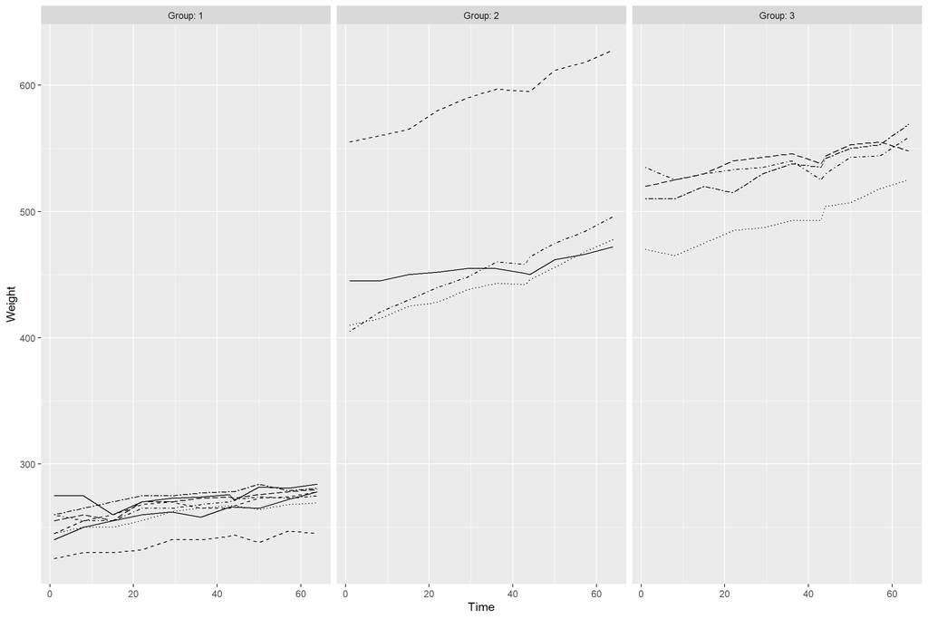

```r
# we use ggplot to creat the parallel plots so that each group of rat is separated for better visualization
ggplot(RATSL, aes(x = Time, y = Weight, linetype = ID)) +
  geom_line() +
  scale_linetype_manual(values = rep(1:10, times=4)) +
  facet_grid(. ~Group, labeller = label_both) +
  theme(legend.position = "none") +
  scale_y_continuous(limits = c(min(RATSL$Weight), max(RATSL$Weight)))
```

This plot produces the weight curves during the time for each group separately. From the plot it would be suggested that rats in group 1 gain the least weight. We can also try if it changes with standardization of the dataset.

```r
RATSL = RATSL %>%
  group_by(Time) %>%
  mutate(stdWeight = (Weight - mean(Weight))/sd(Weight) ) %>%
  ungroup()
```

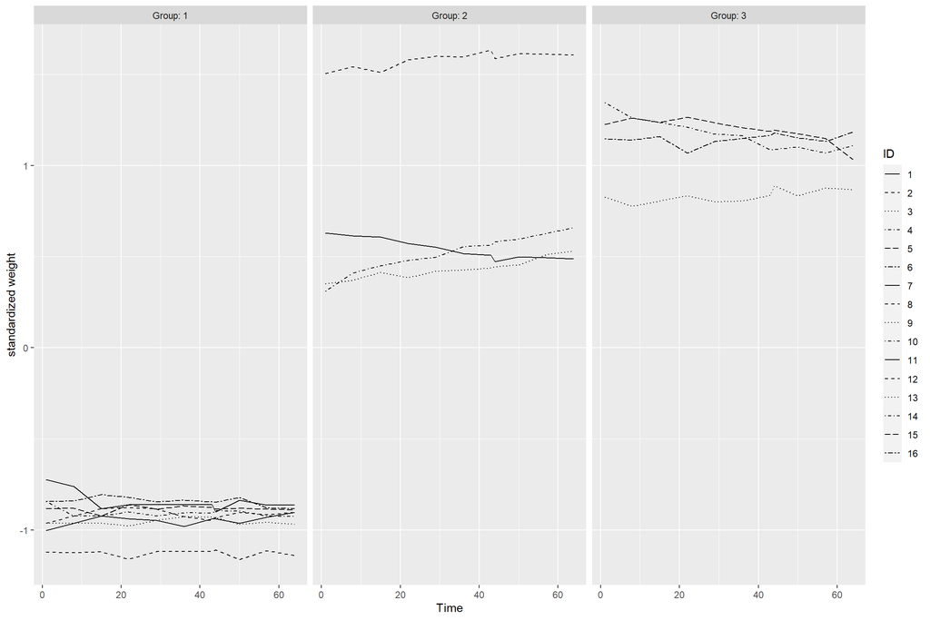

```r
ggplot(RATSL, aes(x = Time, y = stdWeight, linetype = ID)) +
  geom_line() +
  scale_linetype_manual(values = rep(1:10, times=4)) +
  facet_grid(. ~ Group, labeller = label_both) +
  scale_y_continuous(name = "standardized weight")
```

```r
n = 11

RATSS = RATSL %>%
  group_by(Group, Time) %>%
  summarise(mean = mean(Weight), se = sd(Weight)/sqrt(n) ) %>%
  ungroup()
```

Let’s take glimpse of the data.

```r
glimpse(RATSS)
```

```
## Rows: 33
## Columns: 4
## $ Group <fct> 1, 1, 1, 1, 1, 1, 1, 1, 1, 1, 1, 2, 2, 2, 2, 2, 2, 2, 2, 2, 2, 2~
## $ Time  <int> 1, 8, 15, 22, 29, 36, 43, 44, 50, 57, 64, 1, 8, 15, 22, 29, 36, ~
## $ mean  <dbl> 250.625, 255.000, 254.375, 261.875, 264.625, 265.000, 267.375, 2~
## $ se    <dbl> 4.589478, 3.947710, 3.460116, 4.100800, 3.333956, 3.552939, 3.30~
```

We now have the mean values and the standard errors with 11(remember the amount of measures for each rat) x 3 groups = 33 observations (11 for each of the group).

We are now ready to plot this summary data.

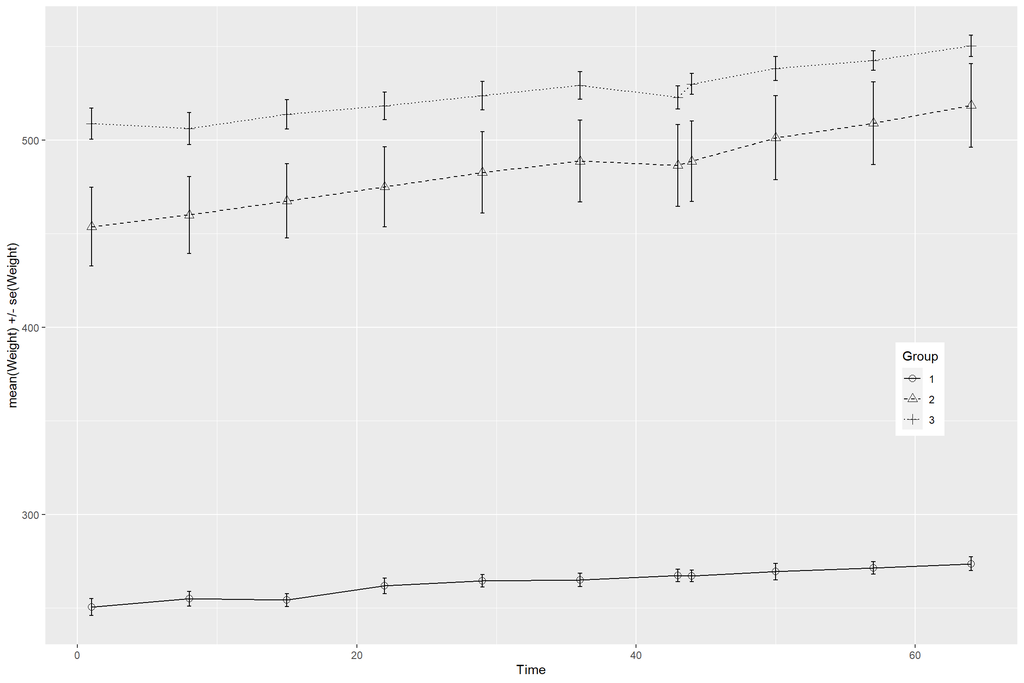

```r
ggplot(RATSS, aes(x = Time, y = mean, linetype = Group, shape = Group)) +
  geom_line() +
  scale_linetype_manual(values = c(1,2,3)) +
  geom_point(size=2.5) +
  scale_shape_manual(values = c(1,2,3)) +
  geom_errorbar(aes(ymin = mean - se, ymax = mean + se, linetype="1"), width=0.3) +
  theme(legend.position = c(0.9, 0.4)) +
  scale_y_continuous(name = "mean(Weight) +/- se(Weight)")
```

Groups 2 and 3 had the least amount of different rats so their standard errors are large, group 2 also had an outlier rat with greater values than other rats in it so the standard errors end up even larger than in the group 3. In general though group 2 and 3 rats seem to end up gaining weight more than group 1 rats although the high standard errors for group make it a bit harder to interpt straight from the plot.

We can do a new summarising without the first week starting measurement.

```r
RATSL10S = RATSL %>%
  filter(Time > 1) %>%
  group_by(Group, ID) %>%
  summarise( mean=mean(Weight) ) %>%
  ungroup()
```

Then let’s glimpse the data.

```r
glimpse(RATSL10S)
```

```
## Rows: 16
## Columns: 3
## $ Group <fct> 1, 1, 1, 1, 1, 1, 1, 1, 2, 2, 2, 2, 3, 3, 3, 3
## $ ID    <fct> 1, 2, 3, 4, 5, 6, 7, 8, 9, 10, 11, 12, 13, 14, 15, 16
## $ mean  <dbl> 263.2, 238.9, 261.7, 267.2, 270.9, 276.2, 274.6, 267.5, 443.9, 4~
```

So now we have the mean weights for weeks 2-11 and the ID’s as well as th rat groups. We can now boxplot it for outliers.

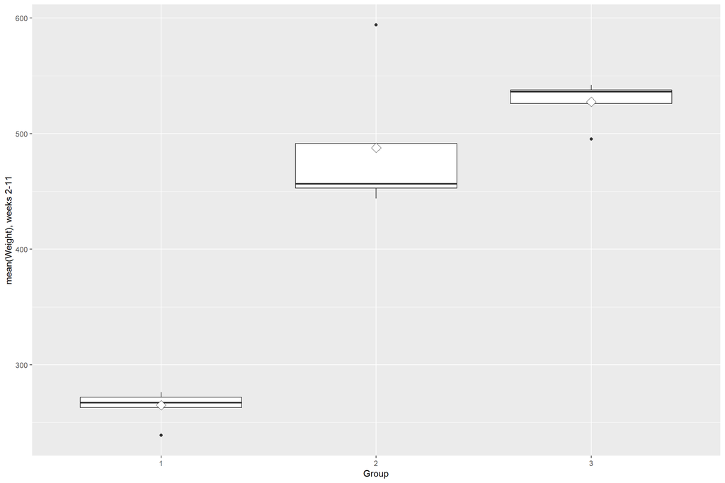

```r
ggplot(RATSL10S, aes(x = Group, y = mean)) +
  geom_boxplot() +
  stat_summary(fun = "mean", geom = "point", shape=23, size=4, fill = "white") +
  scale_y_continuous(name = "mean(Weight), weeks 2-11")
```

The outliers here seem to be below 250 and above 550. For group 3 there is also an outlier at 500 weight though it is in the midde of the dataset even if its seen as an outlier for group 3. We can however use the 250 and 550 as weight limits and remove the ID = 13 outlier from group 3.

```r
RATSL10S1 = RATSL10S %>%
  filter(mean > 250 & mean < 550 & ID != 13)
```

We have now removed the 3 outlier variables from the data. Let’s perform a chisquare-test for dataset now comparing the groups (t-test is now not possible as the grouping variable has 3 groups).

We can do qqplot for normality test for the mean-variable in the RATSL10S1 with the ggbur-package using a density function. For normally distibuted we should see a bell-shaped curve.

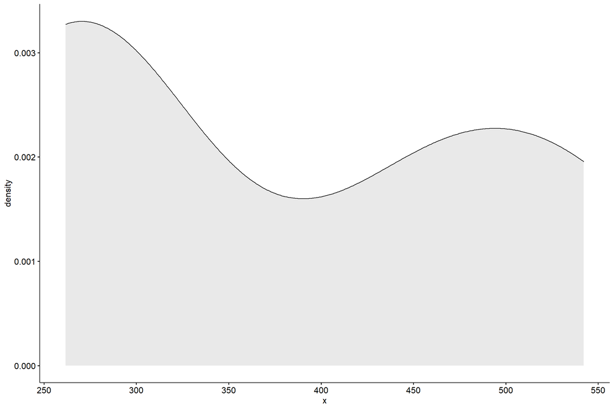

```r
library("ggpubr")
par(mfrow = c(1,1))
ggdensity(RATSL10S1$mean, fill = "lightgray")
```

This definitely does not seem to be normally distributed. However wee can do a non-parametric test with Kruskal-Wallis on the data

```r
kruskal.test(mean ~ Group, data = RATSL10S1)
```

```
##
##  Kruskal-Wallis rank sum test
##
## data:  mean by Group
## Kruskal-Wallis chi-squared = 9.8901, df = 2, p-value = 0.007119
```

This yet again indicates a difference between the group means.

We can do further analysis by adding back the baseline and looking whether there is difference in the growth of weight with a linear model.

```r
RATSL10S2  = RATSL10S %>%
  mutate(baseline = RATS$WD1)
```

```r
#linear model for weight difference
fit.rat = lm(mean ~ baseline + Group, data = RATSL10S2)
summary(fit.rat)
```

```
##
## Call:
## lm(formula = mean ~ baseline + Group, data = RATSL10S2)
##
## Residuals:
##     Min      1Q  Median      3Q     Max
## -23.905  -4.194   2.190   7.577  14.800
##
## Coefficients:
##             Estimate Std. Error t value Pr(>|t|)
## (Intercept) 33.16375   21.87657   1.516   0.1554
## baseline     0.92513    0.08572  10.793 1.56e-07 ***
## Group2      34.85753   18.82308   1.852   0.0888 .
## Group3      23.67526   23.25324   1.018   0.3287
## ---
## Signif. codes:  0 '***' 0.001 '**' 0.01 '*' 0.05 '.' 0.1 ' ' 1
##
## Residual standard error: 11.68 on 12 degrees of freedom
## Multiple R-squared:  0.9936, Adjusted R-squared:  0.992
## F-statistic: 622.1 on 3 and 12 DF,  p-value: 1.989e-13
```

It would seem that the groups do not quite differ in the weight gain after all even though they differ between each other in the baseline as could already be seen the in the plots.

Next we can move onto the blood pressure data(BPRS).

```r
BPRSL_reg <- lm(bprs ~ week + treatment, data = BPRSL)
summary(BPRSL_reg)
```

```
##
## Call:
## lm(formula = bprs ~ week + treatment, data = BPRSL)
##
## Residuals:
##     Min      1Q  Median      3Q     Max
## -22.454  -8.965  -3.196   7.002  50.244
##
## Coefficients:
##             Estimate Std. Error t value Pr(>|t|)
## (Intercept)  46.4539     1.3670  33.982   <2e-16 ***
## week         -2.2704     0.2524  -8.995   <2e-16 ***
## treatment2    0.5722     1.3034   0.439    0.661
## ---
## Signif. codes:  0 '***' 0.001 '**' 0.01 '*' 0.05 '.' 0.1 ' ' 1
##
## Residual standard error: 12.37 on 357 degrees of freedom
## Multiple R-squared:  0.1851, Adjusted R-squared:  0.1806
## F-statistic: 40.55 on 2 and 357 DF,  p-value: < 2.2e-16
```

It would seem that in this model the bprs differs between week but not between the treatment groups. The explanation of the variance of blood pressure is only 18% as well.

We can make an intercept model with the lmer tool in lme4-package.

```r
library("lme4")
BPRS_ref <- lmer(bprs ~ week + treatment + (1 | subject), data = BPRSL, REML = FALSE)
summary(BPRS_ref)
```

```
## Linear mixed model fit by maximum likelihood  ['lmerMod']
## Formula: bprs ~ week + treatment + (1 | subject)
##    Data: BPRSL
##
##      AIC      BIC   logLik deviance df.resid
##   2748.7   2768.1  -1369.4   2738.7      355
##
## Scaled residuals:
##     Min      1Q  Median      3Q     Max
## -3.0481 -0.6749 -0.1361  0.4813  3.4855
##
## Random effects:
##  Groups   Name        Variance Std.Dev.
##  subject  (Intercept)  47.41    6.885
##  Residual             104.21   10.208
## Number of obs: 360, groups:  subject, 20
##
## Fixed effects:
##             Estimate Std. Error t value
## (Intercept)  46.4539     1.9090  24.334
## week         -2.2704     0.2084 -10.896
## treatment2    0.5722     1.0761   0.532
##
## Correlation of Fixed Effects:
##            (Intr) week
## week       -0.437
## treatment2 -0.282  0.000
```

Let’s make a random slope model.

```r
BPRS_ref1 = lmer(bprs ~ week + treatment + (week | subject), data = BPRSL, REML = FALSE)
summary(BPRS_ref1)
```

```
## Linear mixed model fit by maximum likelihood  ['lmerMod']
## Formula: bprs ~ week + treatment + (week | subject)
##    Data: BPRSL
##
##      AIC      BIC   logLik deviance df.resid
##   2745.4   2772.6  -1365.7   2731.4      353
##
## Scaled residuals:
##     Min      1Q  Median      3Q     Max
## -2.8919 -0.6194 -0.0691  0.5531  3.7976
##
## Random effects:
##  Groups   Name        Variance Std.Dev. Corr
##  subject  (Intercept) 64.8222  8.0512
##           week         0.9609  0.9802   -0.51
##  Residual             97.4305  9.8707
## Number of obs: 360, groups:  subject, 20
##
## Fixed effects:
##             Estimate Std. Error t value
## (Intercept)  46.4539     2.1052  22.066
## week         -2.2704     0.2977  -7.626
## treatment2    0.5722     1.0405   0.550
##
## Correlation of Fixed Effects:
##            (Intr) week
## week       -0.582
## treatment2 -0.247  0.000
```

We can check the difference with the ANOVA test.

```r
anova(BPRS_ref1,BPRS_ref)
```

```
## Data: BPRSL
## Models:
## BPRS_ref: bprs ~ week + treatment + (1 | subject)
## BPRS_ref1: bprs ~ week + treatment + (week | subject)
##           npar    AIC    BIC  logLik deviance  Chisq Df Pr(>Chisq)
## BPRS_ref     5 2748.7 2768.1 -1369.4   2738.7
## BPRS_ref1    7 2745.4 2772.6 -1365.7   2731.4 7.2721  2    0.02636 *
## ---
## Signif. codes:  0 '***' 0.001 '**' 0.01 '*' 0.05 '.' 0.1 ' ' 1
```

There does seem to be a difference between the random intercept and random slope models.

Let’s do yet another model, interaction model this time.

```r
BPRS_ref2 = lmer(bprs ~ week * treatment + (week | subject), data = BPRSL, REML = FALSE)
summary(BPRS_ref2)
```

```
## Linear mixed model fit by maximum likelihood  ['lmerMod']
## Formula: bprs ~ week * treatment + (week | subject)
##    Data: BPRSL
##
##      AIC      BIC   logLik deviance df.resid
##   2744.3   2775.4  -1364.1   2728.3      352
##
## Scaled residuals:
##     Min      1Q  Median      3Q     Max
## -3.0512 -0.6271 -0.0768  0.5288  3.9260
##
## Random effects:
##  Groups   Name        Variance Std.Dev. Corr
##  subject  (Intercept) 64.9964  8.0620
##           week         0.9687  0.9842   -0.51
##  Residual             96.4707  9.8220
## Number of obs: 360, groups:  subject, 20
##
## Fixed effects:
##                 Estimate Std. Error t value
## (Intercept)      47.8856     2.2521  21.262
## week             -2.6283     0.3589  -7.323
## treatment2       -2.2911     1.9090  -1.200
## week:treatment2   0.7158     0.4010   1.785
##
## Correlation of Fixed Effects:
##             (Intr) week   trtmn2
## week        -0.650
## treatment2  -0.424  0.469
## wek:trtmnt2  0.356 -0.559 -0.840
```

Now we can do an ANOVA test on these two models to see if it gets better.

```r
anova(BPRS_ref2, BPRS_ref1)
```

```
## Data: BPRSL
## Models:
## BPRS_ref1: bprs ~ week + treatment + (week | subject)
## BPRS_ref2: bprs ~ week * treatment + (week | subject)
##           npar    AIC    BIC  logLik deviance  Chisq Df Pr(>Chisq)
## BPRS_ref1    7 2745.4 2772.6 -1365.7   2731.4
## BPRS_ref2    8 2744.3 2775.4 -1364.1   2728.3 3.1712  1    0.07495 .
## ---
## Signif. codes:  0 '***' 0.001 '**' 0.01 '*' 0.05 '.' 0.1 ' ' 1
```

There doesn’t seem to be a difference between these two models, which suggest that the interaction term doesn’t really improve the situation here, so we can proceed with the ref1 model.

We will create a fitted blood pressure vector with fitted tool used on the ref1 model.

```r
BP.fit = fitted(BPRS_ref1)
```

Let’s put the fitted data back into BPRSL data.

```r
BPRSL = BPRSL %>%
  mutate(BP.fit)
```

Plot the original blood pressure variable.

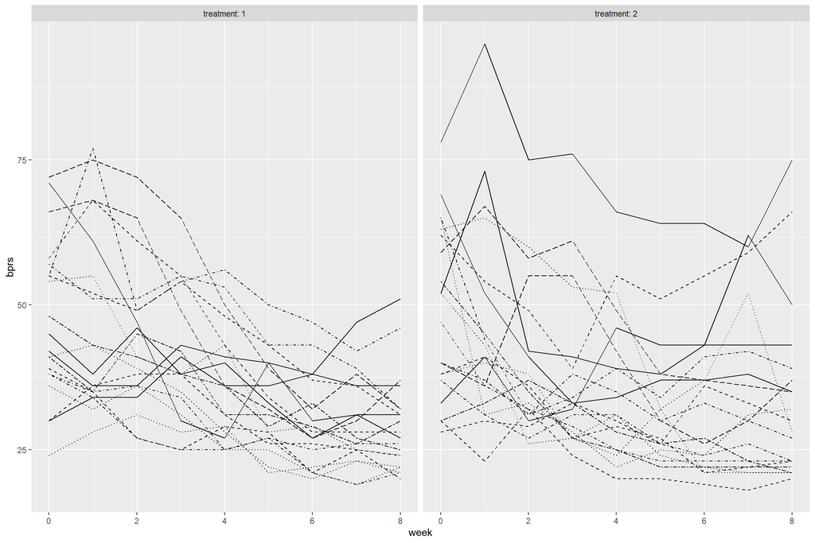

```r
ggplot(BPRSL, aes(x = week, y = bprs, linetype = subject)) +
  geom_line() +
  scale_linetype_manual(values = rep(1:10, times=4)) +
  facet_grid(. ~ treatment, labeller = label_both) +
  theme(legend.position = "none") +
  scale_y_continuous(limits = c(min(BPRSL$bprs), max(BPRSL$bprs)))
```

It is difficult to say from this whether they differ.

Now to compare, plot of the fitted blood pressure variable.

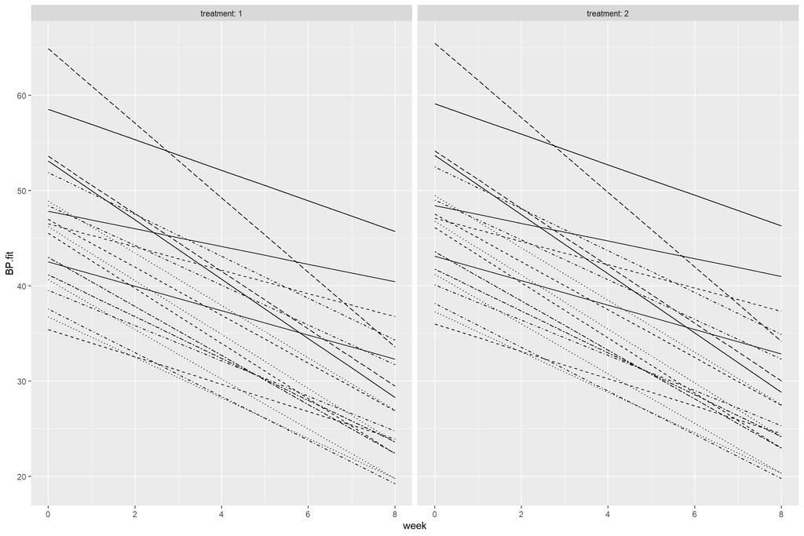

```r
ggplot(BPRSL, aes(x = week, y = BP.fit, linetype = subject)) +
  geom_line() +
  scale_linetype_manual(values = rep(1:10, times=4)) +
  facet_grid(. ~ treatment, labeller = label_both) +
  theme(legend.position = "none") +
  scale_y_continuous(limits = c(min(BPRSL$BP.fit), max(BPRSL$BP.fit)))
```

The fitted models plots definitely don’t seem to differ from each other. We can say with some confidence that the blood pressures did not differ between the treatments or treatments are equally good. The result is also inline with the swapped results you can get from the datacamp.

```r
date()
```

```
## [1] "Fri Dec 10 20:55:35 2021"
```